# Inventory Management for Coffee Shop

This analytical report outlines the process of developing a procurement system and inventory management strategy for a coffee shop in New York City. The analysis is based on historical transactions from one of the stores, utilizing Python as the primary tool for data management, cleaning, analysis, and export. Leveraging a programming language like Python offers the benefits of reproducibility and automation, facilitating future analyses across multiple stores.

## Company's Description

The focus of this study is a rapidly expanding coffee shop chain based in New York City. Established in 2019, the company has grown significantly over the past five years, opening seven additional stores in various neighborhoods throughout the city.

### Company's Mision Statement

To become the leading coffee chain recognized for delivering exceptional quality and unparalleled customer satisfaction.

### Company's Vision Statement

To expand our presence by opening new stores and achieving vertical integration, allowing us to become our own suppliers and ensure the highest standards of quality and sustainability in every cup we serve.

## Problem Description

The company currently lacks a formal procurement system and proper inventory management. As the company has experienced significant growth over the past few years, inventory-related costs have increased accordingly. Presently, store managers handle all procurement based solely on their experience, leading to issues such as overstocking, understocking, and excessive waste. Given the competitive coffee shop landscape in New York City, it is crucial for the company to establish, monitor, and control its procurement activities and inventory management to remain competitive.

## Solution Development

### Methodology

The methodology consists of the following stages:

1. **Data Collection:** Gather historical sales data from the coffee shop.
2. **Data Cleaning:** Prepare the data for analysis by cleaning and organizing it.
3. **Demand Analysis:** Examine demand patterns for each product category.
4. **Inventory Model Development:** Create an inventory model that includes safety stock calculations and reorder points.
5. **Implementation:** Integrate the inventory model into the coffee shop's operations.

Let's start by importing the relevant libraries.

```python
import pandas as pd
import numpy as np
import seaborn as sns
import matplotlib.pyplot as plt
from matplotlib.cbook import boxplot_stats
from scipy import stats
import math
import warnings
warnings.filterwarnings('ignore')
```

Now we import the csv files with the historic transactions.

```python
# Read csv files
sales_2023 = pd.read_csv('Data\StMarks\Sales_2023.csv')
sales_mid2024 = pd.read_csv('Data\StMarks\Sales_mid2024.csv')

# Concatanate transactions of both years in one dataframe
frames = [sales_mid2024, sales_2023]

hist = pd.concat(frames)

# Inspect the size
hist.shape
```

```
(102643, 30)
```

```python
# Inspect the first 5 rows.
hist.head()
```

|  | Date | Time | Time Zone | Category | Item | Qty | Price Point Name | SKU | Modifiers Applied | Gross Sales | ... | Dining Option | Customer ID | Customer Name | Customer Reference ID | Unit | Count | Itemization Type | Commission | Employee | Fulfillment Note |
| --- | --- | --- | --- | --- | --- | --- | --- | --- | --- | --- | --- | --- | --- | --- | --- | --- | --- | --- | --- | --- | --- |
| 0 | 2024-05-15 | 17:50:20 | Eastern Time (US & Canada) | Hot | Cappuccino 10oz\12oz | 2 | 10oz | NaN | NaN | $9.80 | ... | NaN | NaN | NaN | NaN | ea | 2 | Physical Item | $0.00 | Alexa Marcon | NaN |
| 1 | 2024-05-15 | 17:48:25 | Eastern Time (US & Canada) | Chilled | Iced Mocha | 1 | 20 oz. | NaN | Half & Half | $7.25 | ... | NaN | NaN | NaN | NaN | ea | 1 | Physical Item | $0.00 | Alexa Marcon | NaN |
| 2 | 2024-05-15 | 17:48:25 | Eastern Time (US & Canada) | Chilled | Iced Chai Latte | 1 | 16 oz. | NaN | Whole Milk | $5.95 | ... | NaN | NaN | NaN | NaN | ea | 1 | Physical Item | $0.00 | Alexa Marcon | NaN |
| 3 | 2024-05-15 | 17:39:17 | Eastern Time (US & Canada) | Chilled | Iced Cappuccino | 1 | 20 oz. | NaN | Oat Milk | $7.00 | ... | NaN | 0RFAF6Z4S0XHT7TMHWES439Z4M | (781) 628-8829 | NaN | ea | 1 | Physical Item | $0.00 | Alexa Marcon | NaN |
| 4 | 2024-05-15 | 17:32:53 | Eastern Time (US & Canada) | Chilled | Iced Latte | 1 | 16 oz. | NaN | Oat Milk, Lavender syrup | $6.25 | ... | NaN | ZEEKKJ92Q50A1E9HEQBMATX1HW | Anna Fox | NaN | ea | 1 | Physical Item | $0.00 | Alexa Marcon | NaN |

5 rows × 30 columns

```python
# Inspect columns, data types, null values
hist.info()
```

```
<class 'pandas.core.frame.DataFrame'>
Index: 102643 entries, 0 to 58675
Data columns (total 30 columns):
 #   Column                 Non-Null Count   Dtype
---  ------                 --------------   -----
 0   Date                   102643 non-null  object
 1   Time                   102643 non-null  object
 2   Time Zone              102643 non-null  object
 3   Category               99178 non-null   object
 4   Item                   102643 non-null  object
 5   Qty                    102643 non-null  int64
 6   Price Point Name       102568 non-null  object
 7   SKU                    0 non-null       float64
 8   Modifiers Applied      41064 non-null   object
 9   Gross Sales            102643 non-null  object
```

[output cut: 22 more lines]

```python
# Convert 'Date' Column to datetime type
hist['Date'] = pd.to_datetime(hist['Date'])

# Inspect that the change took place
hist.info()
```

```
<class 'pandas.core.frame.DataFrame'>
Index: 102643 entries, 0 to 58675
Data columns (total 30 columns):
 #   Column                 Non-Null Count   Dtype
---  ------                 --------------   -----
 0   Date                   102643 non-null  datetime64[ns]
 1   Time                   102643 non-null  object
 2   Time Zone              102643 non-null  object
 3   Category               99178 non-null   object
 4   Item                   102643 non-null  object
 5   Qty                    102643 non-null  int64
 6   Price Point Name       102568 non-null  object
 7   SKU                    0 non-null       float64
 8   Modifiers Applied      41064 non-null   object
 9   Gross Sales            102643 non-null  object
```

[output cut: 22 more lines]

```python
# Add columns for year and number of week in the year
hist['Year'] = hist['Date'].dt.year
hist['Week'] = hist['Date'].dt.isocalendar().week
hist.insert(1,'Week',hist.pop('Week'))
hist.insert(2, 'Year', hist.pop('Year'))
```

```python
# Eliminate dollar sign from sales and convert to float type

hist[['Gross Sales','Discounts','Net Sales','Tax']].to_string()
hist['Gross Sales'] = hist['Gross Sales'].str.replace('$','').astype('float')
hist['Discounts'] = hist['Discounts'].str.replace('$','').astype('float')
hist['Net Sales'] = hist['Net Sales'].str.replace('$','').astype('float')
hist['Tax'] = hist['Tax'].str.replace('$','').astype('float')

hist.info()
```

```
<class 'pandas.core.frame.DataFrame'>
Index: 102643 entries, 0 to 58675
Data columns (total 32 columns):
 #   Column                 Non-Null Count   Dtype
---  ------                 --------------   -----
 0   Date                   102643 non-null  datetime64[ns]
 1   Week                   102643 non-null  UInt32
 2   Year                   102643 non-null  int32
 3   Time                   102643 non-null  object
 4   Time Zone              102643 non-null  object
 5   Category               99178 non-null   object
 6   Item                   102643 non-null  object
 7   Qty                    102643 non-null  int64
 8   Price Point Name       102568 non-null  object
 9   SKU                    0 non-null       float64
```

[output cut: 24 more lines]

We continue by populating data in the 'Category' column. First, we need to check which items have missing data in the 'Category' column.

```python
hist[hist['Category'].isnull()]['Item'].unique().tolist()
```

```
['Custom Amount',
 'Mocha',
 'Americano',
 'Extra Shot',
 'Water bottle',
 'Macchiato',
 'Día de Muertos Latte',
 'Single origin',
 'Green iced tea',
 'Big spoon bar',
 'OATLY',
 'Brownie']
```

Since we work closely with the daily operations of the coffee shop, we can manually add the items to their appropriate categories.

```python
hist.loc[(hist['Category'].isnull()) & (hist['Item'] == 'Custom Amount'),['Category']] = 'Custom Amount'
hist.loc[(hist['Category'].isnull()) & (hist['Item'] == 'Mocha'),['Category']] = 'Hot'
hist.loc[(hist['Category'].isnull()) & (hist['Item'] == 'Americano'),['Category']] = 'Hot'
hist.loc[(hist['Category'].isnull()) & (hist['Item'] == 'Extra Shot'),['Category']] = 'Extra Shot'
hist.loc[(hist['Category'].isnull()) & (hist['Item'] == 'Water bottle'),['Category']] = 'Display Fridge'
hist.loc[(hist['Category'].isnull()) & (hist['Item'] == 'Macchiato'),['Category']] = 'Hot'
hist.loc[(hist['Category'].isnull()) & (hist['Item'] == 'Día de Muertos Latte'),['Category']] = 'Hot'
hist.loc[(hist['Category'].isnull()) & (hist['Item'] == 'Single origin'),['Category']] = 'Beans Bag'
hist.loc[(hist['Category'].isnull()) & (hist['Item'] == 'Green iced tea'),['Category']] = 'Chilled'
hist.loc[(hist['Category'].isnull()) & (hist['Item'] == 'Big spoon bar'),['Category']] = 'Snacks'
```

The quantity of material used in every drink prepared depends directly on the size of the item. The size information it's imbedded into a string in the "Price Point Name" column. In order to extract this info it is necessary to use some parsing techniques.

```python
#Extract size from Price Point column and keep only numeric values for drinks.

hist['Size'] = hist['Price Point Name'].str.extract(r'(\d+[.\d]*)').astype('float') # We extract only the numbers characters from the column and add the values as float in the new column.
hist.insert(6, 'Size', hist.pop('Size')) # Organize the order of columns

# Inspect results
hist.head()
```

|  | Date | Week | Year | Time | Time Zone | Category | Size | Item | Qty | Price Point Name | ... | Dining Option | Customer ID | Customer Name | Customer Reference ID | Unit | Count | Itemization Type | Commission | Employee | Fulfillment Note |
| --- | --- | --- | --- | --- | --- | --- | --- | --- | --- | --- | --- | --- | --- | --- | --- | --- | --- | --- | --- | --- | --- |
| 0 | 2024-05-15 | 20 | 2024 | 17:50:20 | Eastern Time (US & Canada) | Hot | 10.0 | Cappuccino 10oz\12oz | 2 | 10oz | ... | NaN | NaN | NaN | NaN | ea | 2 | Physical Item | $0.00 | Alexa Marcon | NaN |
| 1 | 2024-05-15 | 20 | 2024 | 17:48:25 | Eastern Time (US & Canada) | Chilled | 20.0 | Iced Mocha | 1 | 20 oz. | ... | NaN | NaN | NaN | NaN | ea | 1 | Physical Item | $0.00 | Alexa Marcon | NaN |
| 2 | 2024-05-15 | 20 | 2024 | 17:48:25 | Eastern Time (US & Canada) | Chilled | 16.0 | Iced Chai Latte | 1 | 16 oz. | ... | NaN | NaN | NaN | NaN | ea | 1 | Physical Item | $0.00 | Alexa Marcon | NaN |
| 3 | 2024-05-15 | 20 | 2024 | 17:39:17 | Eastern Time (US & Canada) | Chilled | 20.0 | Iced Cappuccino | 1 | 20 oz. | ... | NaN | 0RFAF6Z4S0XHT7TMHWES439Z4M | (781) 628-8829 | NaN | ea | 1 | Physical Item | $0.00 | Alexa Marcon | NaN |
| 4 | 2024-05-15 | 20 | 2024 | 17:32:53 | Eastern Time (US & Canada) | Chilled | 16.0 | Iced Latte | 1 | 16 oz. | ... | NaN | ZEEKKJ92Q50A1E9HEQBMATX1HW | Anna Fox | NaN | ea | 1 | Physical Item | $0.00 | Alexa Marcon | NaN |

5 rows × 33 columns

There are some drinks that don't have information about the size. We are going to identify this drinks and populate the data.

```python
hist[hist['Size'].isnull()]['Item'].unique()
```

```
array(['Croissant', 'Pierogi', 'Scone', 'Tea', 'Macaron',
       'Water aluminum', 'Cortado 4oz', 'Espresso 2oz',
       'Extra Matcha (1 scoop)', 'Cinnamon Roll', 'Extra Shot',
       'Iced Cortado', 'London Fog 16oz', 'Yogurt', 'Matcha Tea', 'Syrup',
       '1.50$ pastry after 3pm', 'Macchiato 3oz', 'Natalieâ€™s Juice',
       'Bottled Galvanina', 'Beans', 'Milk Cup', 'Custom Amount',
       'Marocchino', 'Small Water', 'Soda', 'Matcha Sunrise', 'Cookie',
       'Big spoon bar', 'Kombucha', 'Día de Muertos Latte',
       'Water bottle', 'Espresso', 'Macchiato', 'Cortado',
       'Single origin', 'Apple Turnover',
       'Saratoga Sparkling/ Still Bottle', 'Flat White 8oz\\12oz',
       'The Poetica', '8oz Flat White', '12 oz. Beans Bag',
       'Iced Mtch. TEA', 'Arnold Palmer', 'London Fog', 'OATLY', 'Muffin',
       'Lemon Bar', 'Brownie', 'Lemonade', 'Flat White'], dtype=object)
```

From the array we identify several drinks that don't have size information. Most of this items only have one size except for "The Poetica" which has two. So the next step requires us to add that data into our `'Size'` column.

```python
hist.loc[(hist['Item'] == 'The Poetica') & (hist['Price Point Name'] == 'Small'),'Size'] = 12.
hist.loc[(hist['Item'] == 'The Poetica') & (hist['Price Point Name'] == 'Large'),'Size'] = 16.
```

Before continuing adding sizes in the `'Size'` column, we first need to standarize the drinks name. Since the early days of the store, the POS system has been updated several times and with every update some names have changed.

```python
sorted(hist['Item'].unique().tolist())
```

```
['1.50$ pastry after 3pm',
 '10 Oz Cappuccino',
 '10oz Cappuccino',
 '12 oz. Beans Bag',
 '8oz Flat White',
 'Americano',
 'Americano 10oz\\12oz\\16oz',
 'Americano 12oz\\16oz',
 'Apple Turnover',
 'Arnold Palmer',
 'Beans',
 'Big spoon bar',
 'Bottled Galvanina',
 'Brownie',
 'Cappuccino',
 'Cappuccino 10oz\\12oz',
 'Chai Latte',
 'Chaider',
 'Chaider Ice',
 'Cider apple',
 'Cider apple Ice',
 'Cinnamon Roll',
 'Cold Brew',
 'Cookie',
 'Cortado',
 'Cortado 4oz',
 'Croissant',
 'Custom Amount',
 'Drip Coffee',
 'Día de Muertos Latte',
 'Elderberry hibiscus iced tea',
 'Espresso',
 'Espresso 2oz',
 'Extra Matcha (1 scoop)',
 'Extra Shot',
 'Flat White',
 'Flat White 8oz',
 'Flat White 8oz\\12oz',
 'Green iced tea',
 'Hot Chocolate',
```

[output cut: 34 more lines]

```
 'OATLY',
 'Pierogi',
 'Saratoga Sparkling/ Still Bottle',
 'Scone',
 'Signature Poetica',
 'Single origin',
 'Small Water',
 'Soda',
 'Special Latte',
 'Syrup',
 'Tea',
 'The Poetica',
 'Water aluminum',
 'Water bottle',
 'Yogurt']
```

In the previous list we can see how the cappuccino is refered as '10 oz Cappuccino' and '10oz Cappuccino'. we are going to follow the next algorithm to select the most recent name and update all items.

```python
# We select the latest item entry so we will know that it will match up with future entries
recent_name = hist.loc[(hist['Item'].str.contains('Cappuccino', regex=False)) & (hist['Category'] == 'Hot') & (hist['Date'] == max(hist['Date']))]['Item'].unique()[0]

# Now we change the name in the data frame
hist.loc[(hist['Item'].str.contains('Cappuccino', regex=False)) & (hist['Category'] == 'Hot'),'Item'] = recent_name

# Make sure the change took place correctly
hist.loc[(hist['Item'].str.contains('Cappuccino', regex=False)) & (hist['Category'] == 'Hot')]['Item'].unique()
```

```
array(['Cappuccino 10oz\\12oz'], dtype=object)
```

We are going to build a custom function that is going to help out to update names in the dataframe.

```python
def update_names(df ,item , col, cat):
    '''df --> Dataframe that will be updated
        item --> The search substring
        col --> Column to look in
        cat --> Category of items '''
    rec_name = df.loc[(df[col].str.contains(item, regex=False)) & (df['Category'] == cat) & (df['Date'] == max(df['Date']))][col].unique()[0]
    df.loc[(df[col].str.contains(item, regex=False)) & (df['Category'] == cat), col] = rec_name
```

```python
# Try the function
update_names(hist, 'Americano', 'Item', 'Hot')

# Inspect results
sorted(hist['Item'].unique().tolist())
```

```
['1.50$ pastry after 3pm',
 '12 oz. Beans Bag',
 '8oz Flat White',
 'Americano 12oz\\16oz',
 'Apple Turnover',
 'Arnold Palmer',
 'Beans',
 'Big spoon bar',
 'Bottled Galvanina',
 'Brownie',
 'Cappuccino 10oz\\12oz',
 'Chai Latte',
 'Chaider',
 'Chaider Ice',
 'Cider apple',
 'Cider apple Ice',
 'Cinnamon Roll',
 'Cold Brew',
 'Cookie',
 'Cortado',
 'Cortado 4oz',
 'Croissant',
 'Custom Amount',
 'Drip Coffee',
 'Día de Muertos Latte',
 'Elderberry hibiscus iced tea',
 'Espresso',
 'Espresso 2oz',
 'Extra Matcha (1 scoop)',
 'Extra Shot',
 'Flat White',
 'Flat White 8oz',
 'Flat White 8oz\\12oz',
 'Green iced tea',
 'Hot Chocolate',
 'Hot Chocolate 12oz\\16oz',
 'Iced Americano',
 'Iced Americano 16oz\\20oz',
 'Iced Black Tea',
 'Iced Cappuccino',
```

[output cut: 29 more lines]

```
 'OATLY',
 'Pierogi',
 'Saratoga Sparkling/ Still Bottle',
 'Scone',
 'Signature Poetica',
 'Single origin',
 'Small Water',
 'Soda',
 'Special Latte',
 'Syrup',
 'Tea',
 'The Poetica',
 'Water aluminum',
 'Water bottle',
 'Yogurt']
```

From the previous results we can see that the algorithm and the helper function works. Now we are going to use a for loop to iterate through the different drinks and update the names.

```python
# Create list with the name of the different hot drinks
names_hot = ['Flat White','Cortado', 'Espresso', 'Hot Chocolate', 'London Fog','Poetica']

# Iterate through every item in the list and update name with most recent one
for it in names_hot:
    update_names(hist, it, 'Item', 'Hot')

# Update name for Iced Americano
update_names(hist, 'Iced Americano', 'Item', 'Chilled')

# Manually update name for the Macchianto
hist.loc[(hist['Item'] == 'Macchiato'),['Item']] = 'Macchiato 3oz'
```

Since the key word 'Latte' is used in different items we are going to update the 'Latte' items separetly.

```python
# First we create a list with the different names for latte
latte_names = ['Latte', 'Latte 12oz\\16oz', 'Special Latte']

# Second we establish the most recent name for the latte items
rec_latte = hist.loc[(hist['Category'] == 'Hot') & (hist['Item'].isin(latte_names)) & (hist['Date'] == max(hist['Date']))]['Item'].unique()[0]
print(rec_latte)

# We remove the most recent name from the latte_names list since we don't have to update those values
latte_names.remove(rec_latte)
print(latte_names)

# Third we change the old names of the drinks for the most recent one
hist.loc[(hist['Item'].isin(latte_names)),'Item'] = rec_latte
```

```
Latte 12oz\16oz
['Latte', 'Special Latte']
```

Next steps is to create and standarize a milk column. Milk information is in the `'Modifiers'` columns, some instances contain information about syrups. For some drinks such as cold brew, drip, etc..., syrups are at the start of the string while in the rest of the drinks syrups are at the end. We'll need to extract this information and put them in their right column. Milk names also change throughout the data frame, we will need to standarize them.

```python
# Max Number of commas to extract each string to its own column
max_commas = hist.loc[(hist['Modifiers Applied'].notnull())]['Modifiers Applied'].str.split(',').transform(len).max()
print(max_commas)
```

```
4
```

```python
# Split string and have one column each
hist[[f'Mod_{x+1}' for x in range(max_commas)]] = hist['Modifiers Applied'].str.split(',', expand=True)

# Rearrange column order
hist.insert(12, 'Mod_1', hist.pop('Mod_1'))
hist.insert(13, 'Mod_2', hist.pop('Mod_2'))
hist.insert(14, 'Mod_3', hist.pop('Mod_3'))
hist.insert(15, 'Mod_4', hist.pop('Mod_4'))
```

```python
# Check results
hist.head()
```

|  | Date | Week | Year | Time | Time Zone | Category | Size | Item | Qty | Price Point Name | ... | Dining Option | Customer ID | Customer Name | Customer Reference ID | Unit | Count | Itemization Type | Commission | Employee | Fulfillment Note |
| --- | --- | --- | --- | --- | --- | --- | --- | --- | --- | --- | --- | --- | --- | --- | --- | --- | --- | --- | --- | --- | --- |
| 0 | 2024-05-15 | 20 | 2024 | 17:50:20 | Eastern Time (US & Canada) | Hot | 10.0 | Cappuccino 10oz\12oz | 2 | 10oz | ... | NaN | NaN | NaN | NaN | ea | 2 | Physical Item | $0.00 | Alexa Marcon | NaN |
| 1 | 2024-05-15 | 20 | 2024 | 17:48:25 | Eastern Time (US & Canada) | Chilled | 20.0 | Iced Mocha | 1 | 20 oz. | ... | NaN | NaN | NaN | NaN | ea | 1 | Physical Item | $0.00 | Alexa Marcon | NaN |
| 2 | 2024-05-15 | 20 | 2024 | 17:48:25 | Eastern Time (US & Canada) | Chilled | 16.0 | Iced Chai Latte | 1 | 16 oz. | ... | NaN | NaN | NaN | NaN | ea | 1 | Physical Item | $0.00 | Alexa Marcon | NaN |
| 3 | 2024-05-15 | 20 | 2024 | 17:39:17 | Eastern Time (US & Canada) | Chilled | 20.0 | Iced Cappuccino | 1 | 20 oz. | ... | NaN | 0RFAF6Z4S0XHT7TMHWES439Z4M | (781) 628-8829 | NaN | ea | 1 | Physical Item | $0.00 | Alexa Marcon | NaN |
| 4 | 2024-05-15 | 20 | 2024 | 17:32:53 | Eastern Time (US & Canada) | Chilled | 16.0 | Iced Latte | 1 | 16 oz. | ... | NaN | ZEEKKJ92Q50A1E9HEQBMATX1HW | Anna Fox | NaN | ea | 1 | Physical Item | $0.00 | Alexa Marcon | NaN |

5 rows × 37 columns

```python
# All milk names in Column Mod_1 and with most recent name

# Create empty list to store recent names since we are going to be using this information later on to reorganize the data in their correct columns
rec_milk_arr = []

# List with milk key words used to search and filter
key_words = ['Whole', 'Skim', 'Oat', 'Almond', 'Half']

# List with the names of the columns where we are going to search for milk entries
col_names = ['Mod_1', 'Mod_2', 'Mod_3', 'Mod_4']

# Start iteration using the key words to filter rows in each column
for milk in key_words:
    # Find most recent name and add it to the list
    rec_name = hist.loc[(hist['Mod_1'].str.contains(milk, regex=False)) & (hist['Date'] == max(hist['Date']))]['Mod_1'].unique()[0]
    rec_milk_arr.append(rec_name)
    # Start looping around each column looking for milk and updating to the most recent name
    for col in col_names:
        hist.loc[(hist[col] != rec_name) & (hist[col].str.contains(milk, regex=False)), col] = rec_name
```

```python
# Regular is also used to refer to whole milk

for col in col_names:
     hist.loc[(hist[col] == ' Regular'), col] = rec_milk_arr[0]
```

All milk should be in Mod_1, only Mod_1 and Mod_2 contain milk in the same row, this means that the drink was made with a mix of milks. There are 72 rows where this happens.

```python
# Create masks to access the rows that we are switching

# Just access data milk in Mod_1
m1 = hist['Mod_1'].isin(rec_milk_arr)

# Access data milk in Mod_2
m2 = hist['Mod_2'].isin(rec_milk_arr)

# Add all the milk values from 'Mod_2' to 'Mod_1'
hist.loc[~m1 & m2, ['Mod_1', 'Mod_2']] = hist.loc[~m1 & m2, ['Mod_2', 'Mod_1']].values
```

Finish adding sizes to the column `'Size'` for drinks that only have one size. Such as espresso, cortado, macchiato, and flat white.

```python
# Create dictionary with the sizes of each drink
drink_size = {'Espresso 2oz': 4., 'Macchiato 3oz': 4., 'Cortado 4oz': 8., 'Flat White 8oz': 8., 'London Fog 16oz': 16., 'Tea': 16., 'Iced Cortado': 16., 'Iced Mtch. TEA': 16., 'Día de Muertos Latte': 12., 'Marocchino': 4., 'Matcha Sunrise': 16., 'Matcha Tea': 16., 'Milk Cup': 12.}

# Iterate through every key in the dictionary and add their correspondent value in the data frame.
for drink in drink_size.keys():
    hist.loc[hist['Item'] == drink, 'Size'] = drink_size[drink]
```

```python
# Add milk information to drinks with Au lait as their modifier

# Filter data with 'Au lait' as their modifier
m1 = hist['Mod_1'] == 'Au lait (steamed milk)'

# Filter data where there is no information in 'Mod_2'
m2 = hist['Mod_2'].isnull()

# Update the values
hist.loc[m1 & m2,'Mod_2'] = hist.loc[m1 & m2,'Mod_1']
hist.loc[m1 & m2,'Mod_1'] = 'Whole Milk'
```

So far we've standardized the drink names, assigned sizes, and organized the location and milk names into columns, we've also filled in the necessary NULL values. This was all accomplished using DataFrames, arrays, lists, dictionaries, and both custom and built-in functions. Next, we’ll save the DataFrame and proceed to create new tables derived from the historical transactions. These DataFrames will track daily consumption of each item and the materials needed (e.g., cups by size, milk). They will help us understand demand, forecast future needs, and establish material requirements and reordering strategies. We'll be applying restocking models, inventory theory, and some statistical analysis to align the demand with an appropriate model.

### Prepare Demand tables per Material

From the cleaned data frame we are going to make sub sets of the different items in order to create tables with the demand of each material.

```python
# Import cleaned csv file
hist = pd.read_csv('Historic_Sales_StMarks_Cleaned.csv')

# Create data frame with only columns needed for drinks
drinks_df = hist[['Date', 'Week', 'Year', 'Category', 'Size', 'Item', 'Qty', 'Mod_1']]
```

Import table with information about the milk consumption for each different drink.

```python
rules = pd.read_csv('Milk_Rules - Hoja 1.csv', index_col='Item')
rules.head()
```

| Item | 4.0 | 8.0 | 10.0 | 12.0 | 16.0 | 20.0 |
| --- | --- | --- | --- | --- | --- | --- |
| Americano 12oz\16oz | 0 | 0 | 0 | 2 | 2.0 | 0.0 |
| Arnold Palmer | 0 | 0 | 0 | 0 | 0.0 | 0.0 |
| Cappuccino 10oz\12oz | 0 | 0 | 6 | 7 | 0.0 | 0.0 |
| Chai Latte | 0 | 0 | 0 | 5 | 7.0 | 0.0 |
| Chaider | 0 | 0 | 0 | 0 | 0.0 | 0.0 |

The rules data frame is going to be converted into a dictionary. The advantage in having this set of rules in a dictionary is that is going to let us simulate a famous excel formula `'XLOOKUP'`. For every drink in `drinks_df` we are going to look up the drink and the size in the `rules_dict`.

```python
rules_dict = rules.to_dict()
print(rules_dict)
```

```
{'4.0': {'Americano 12oz\\16oz': 0, 'Arnold Palmer': 0, 'Cappuccino 10oz\\12oz': 0, 'Chai Latte': 0, 'Chaider': 0, 'Chaider Ice': 0, 'Cider apple': 0, 'Cider apple Ice': 0, 'Cold Brew': 0, 'Cortado 4oz': 0, 'Día de Muertos Latte': 0, 'Drip Coffee': 0, 'Elderberry hibiscus iced tea': 0, 'Espresso 2oz…
```

As we can see in the previous `print`, we've created a **nested dictionary** with the different cup sizes as the main dictionary. Each of these keys contains a dictionary with information on how much milk is needed to prepare that drink in the corresponding size.

Let's also create a DataFrame where we'll store the milk demand information.

```python
milk_df = drinks_df[['Date', 'Week','Year']]
```

```python
# Add Milk quantities in drink data frame.

# In the following for loop, we simulate excel's xlookup formula. We filter the values with keys from the nested dictionary and add the correct value to the column
for key in rules_dict.keys():
    for item in rules_dict[key].keys():
        drinks_df.loc[(drinks_df['Item'] == item) & (drinks_df['Size'] == float(key)), 'Milk_Qty'] = rules_dict[key][item]
```

```python
milk_df.info()
drinks_df.info()
```

```
<class 'pandas.core.frame.DataFrame'>
RangeIndex: 102643 entries, 0 to 102642
Data columns (total 3 columns):
 #   Column  Non-Null Count   Dtype
---  ------  --------------   -----
 0   Date    102643 non-null  object
 1   Week    102643 non-null  int64
 2   Year    102643 non-null  int64
dtypes: int64(2), object(1)
memory usage: 2.3+ MB
<class 'pandas.core.frame.DataFrame'>
RangeIndex: 102643 entries, 0 to 102642
Data columns (total 9 columns):
 #   Column    Non-Null Count   Dtype
---  ------    --------------   -----
 0   Date      102643 non-null  object
 1   Week      102643 non-null  int64
 2   Year      102643 non-null  int64
 3   Category  102621 non-null  object
 4   Size      78316 non-null   float64
 5   Item      102643 non-null  object
 6   Qty       102643 non-null  int64
 7   Mod_1     41064 non-null   object
 8   Milk_Qty  78214 non-null   float64
dtypes: float64(2), int64(3), object(4)
memory usage: 7.0+ MB
```

Now we can start creating our milk demand summary table.

```python
# List containing milk names that is going to be useful to lookup values in drink_df and is going to work as the column names in milk_df
milk_list = ['Whole Milk', 'Skim Milk', 'Half & Half', 'Oat Milk', 'Almond Milk']

# Start for loop around our milk name list
for milk in milk_list:
    # Create mask filtering only those drinks that contain the specific milk
    m1 = drinks_df['Mod_1'] == milk
    # Create new column in milk_df with Milk_Qty as values. We are multiplying the values times the amount of drink ordered during the transaction.
    milk_df.loc[m1, milk] = drinks_df.loc[m1,'Milk_Qty'] * drinks_df.loc[m1,'Qty']
```

```python
# Check results
milk_df.loc[(drinks_df['Item'] == 'Latte 12oz\\16oz') & (drinks_df['Mod_1'].isin(milk_list))]
```

|  | Date | Week | Year | Whole Milk | Skim Milk | Half & Half | Oat Milk | Almond Milk |
| --- | --- | --- | --- | --- | --- | --- | --- | --- |
| 24 | 2024-05-15 | 20 | 2024 | NaN | 8.0 | NaN | NaN | NaN |
| 48 | 2024-05-15 | 20 | 2024 | NaN | NaN | NaN | 8.0 | NaN |
| 54 | 2024-05-15 | 20 | 2024 | NaN | NaN | NaN | 11.0 | NaN |
| 93 | 2024-05-15 | 20 | 2024 | 8.0 | NaN | NaN | NaN | NaN |
| 99 | 2024-05-15 | 20 | 2024 | NaN | 8.0 | NaN | NaN | NaN |
| ... | ... | ... | ... | ... | ... | ... | ... | ... |
| 102541 | 2023-04-26 | 17 | 2023 | NaN | NaN | NaN | NaN | 11.0 |
| 102566 | 2023-04-25 | 17 | 2023 | NaN | NaN | NaN | 8.0 | NaN |
| 102599 | 2023-04-25 | 17 | 2023 | 8.0 | NaN | NaN | NaN | NaN |
| 102605 | 2023-04-25 | 17 | 2023 | NaN | NaN | NaN | NaN | 11.0 |
| 102606 | 2023-04-25 | 17 | 2023 | NaN | NaN | NaN | 8.0 | NaN |

5570 rows × 8 columns

Some drinks were not registered with any type of milk, even though their recipes clearly indicate they contain milk. We need to add the corresponding milk usage to each of these drinks. Since the company charges extra for alternative milks, we'll assume that the milk used in the preparation was either whole or skim milk (they don't generate any extra cost to the customer). We'll calculate the proportion of each type of milk and populate the data accordingly.

```python
# Total ounces of whole milk used
tot_wm = milk_df['Whole Milk'].sum()

# Total ounces of skim milk used
tot_skm = milk_df['Skim Milk'].sum()

# Proportion of whole milk
prop_wm = tot_wm/(tot_wm + tot_skm)

# Proportion of skim milk
prop_skm = tot_skm/(tot_wm + tot_skm)

# Print values
print(prop_wm, prop_skm)
```

```
0.8252165460937895 0.1747834539062105
```

We start by creating the item list and the two masks we are going to use to filter our data.

```python
# Create drink array
drink_arr = ['Cappuccino 10oz\\12oz',	'Iced Chai Latte',	'Iced Mocha',	'Cortado 4oz',	'Hot Chocolate 12oz\\16oz',	'Flat White 8oz',	'Latte 12oz\\16oz',	'Iced Latte',	'Iced Matcha',	'Iced Poetica',	'Iced Cortado',	'London Fog 16oz',	'Chai Latte',	'Mocha',	'The Poetica',	'Iced Cappuccino',	'Macchiato 3oz',	'Milk Cup',	'Matcha Latte',	'Marocchino',	'Iced Special Latte',	'Día de Muertos Latte']

# We are going to look only at the items in the array
m1 = drinks_df['Item'].isin(drink_arr)

# Items containing milk information
m2 = drinks_df['Mod_1'].isin(milk_list)

# Filtering drinks_df with AND statement where we are only returning drink items not containing milk information.
drinks_df.loc[m1 & ~m2].info()
```

```
<class 'pandas.core.frame.DataFrame'>
Index: 16119 entries, 0 to 102629
Data columns (total 9 columns):
 #   Column    Non-Null Count  Dtype
---  ------    --------------  -----
 0   Date      16119 non-null  object
 1   Week      16119 non-null  int64
 2   Year      16119 non-null  int64
 3   Category  16119 non-null  object
 4   Size      16119 non-null  float64
 5   Item      16119 non-null  object
 6   Qty       16119 non-null  int64
 7   Mod_1     2382 non-null   object
 8   Milk_Qty  16119 non-null  float64
dtypes: float64(2), int64(3), object(4)
memory usage: 1.2+ MB
```

As we can see in the previous summary, there are over 16,000 drink entries missing their milk consumption data. If we continue with our analysis without addressing these gaps, the results that management will base their decisions on would be incorrect. So, we’ll proceed to populate the missing data.

```python
# Gives us the amount of entries we need to populate (+16k)
m = (m1 & ~m2).sum()
print(m)

# We use the numpy function of random.choice to generate an array of size = m, randomly choosing between both values considering the original proportion in the dataframe.
s = np.random.choice(['Whole Milk', 'Skim Milk'],
                     p=[prop_wm, 1-prop_wm],
                     size = m)

# We add thos evalues in their respective place
drinks_df.loc[m1 & ~m2,'Mod_1'] = s
```

```
16119
```

```python
# Check results
drinks_df.loc[m1 & ~m2,'Mod_1'].value_counts()
```

```
Mod_1
Whole Milk    13353
Skim Milk      2766
Name: count, dtype: int64
```

```python
# Let's add those entries in our milk demand table.
for milk in ['Whole Milk', 'Skim Milk']:
    # Create mask that filters our data only with whole or skim milk
    m3 = drinks_df['Mod_1'] == milk
    # Mask 1 and 2 gives us the position where the missing values used to be. Combining those masks with mask 3 gives us the right place where to add the information.
    milk_df.loc[m1 & ~m2 & m3 , milk] = drinks_df.loc[m1 & ~m2 & m3,'Milk_Qty'] * drinks_df.loc[m1 & ~m2 & m3,'Qty']
```

Now we are going to creat 2 tables, the first one we are going to group the data by the day and the second we will group by the week of the year.

```python
summ_day_milk_demand = milk_df[['Date','Whole Milk', 'Skim Milk', 'Half & Half', 'Oat Milk', 'Almond Milk']].groupby(by='Date').sum().sort_values(['Date']).reset_index()
summ_day_milk_demand.head()
```

|  | Date | Whole Milk | Skim Milk | Half & Half | Oat Milk | Almond Milk |
| --- | --- | --- | --- | --- | --- | --- |
| 0 | 2023-04-25 | 122.80 | 30.88 | 2.0 | 158.12 | 29.60 |
| 1 | 2023-04-26 | 260.28 | 27.30 | 4.0 | 166.14 | 98.34 |
| 2 | 2023-04-27 | 189.52 | 32.30 | 2.0 | 167.96 | 45.04 |
| 3 | 2023-04-28 | 303.93 | 84.76 | 14.0 | 333.86 | 105.73 |
| 4 | 2023-04-29 | 228.73 | 70.16 | 6.0 | 293.60 | 42.46 |

```python
summ_week_milk_demand = milk_df[['Week', 'Year','Whole Milk', 'Skim Milk', 'Half & Half', 'Oat Milk', 'Almond Milk']].groupby(by=['Week', 'Year']).sum().sort_values(['Year','Week'], ascending=[True,True]).reset_index()
summ_week_milk_demand.head()
```

|  | Week | Year | Whole Milk | Skim Milk | Half & Half | Oat Milk | Almond Milk |
| --- | --- | --- | --- | --- | --- | --- | --- |
| 0 | 17 | 2023 | 1404.22 | 275.28 | 34.00 | 1380.54 | 392.93 |
| 1 | 18 | 2023 | 2488.28 | 342.33 | 105.60 | 2209.19 | 634.31 |
| 2 | 19 | 2023 | 2532.04 | 381.46 | 80.30 | 2217.01 | 685.91 |
| 3 | 20 | 2023 | 2836.61 | 502.06 | 117.90 | 1999.93 | 773.60 |
| 4 | 21 | 2023 | 2031.48 | 381.82 | 147.34 | 1800.50 | 762.46 |

## Visualization

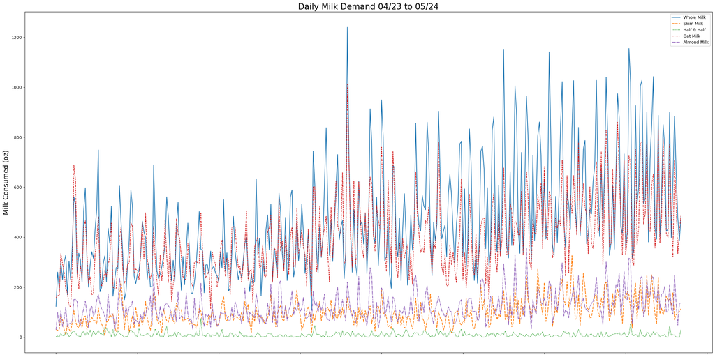

```python
plt.figure(figsize=(30,15))
ax = sns.lineplot(data=summ_day_milk_demand[['Whole Milk', 'Skim Milk', 'Half & Half', 'Oat Milk', 'Almond Milk']])
ax.set_xticklabels('')
ax.set_ylabel('Milk Consumed (oz)', size=16)
ax.set_title('Daily Milk Demand 04/23 to 05/24', size=20);
```

```python
summ_week_milk_demand['Week-Year'] = summ_week_milk_demand['Week'].astype(str) + 'W ' + summ_week_milk_demand['Year'].astype(str) + 'Y'
summ_week_milk_demand.tail()
```

|  | Week | Year | Whole Milk | Skim Milk | Half & Half | Oat Milk | Almond Milk | Week-Year |
| --- | --- | --- | --- | --- | --- | --- | --- | --- |
| 51 | 16 | 2024 | 4765.62 | 990.45 | 71.90 | 3708.26 | 1052.15 | 16W 2024Y |
| 52 | 17 | 2024 | 4982.01 | 1115.69 | 73.60 | 3831.71 | 1230.39 | 17W 2024Y |
| 53 | 18 | 2024 | 4279.17 | 801.64 | 66.00 | 3826.06 | 1168.62 | 18W 2024Y |
| 54 | 19 | 2024 | 4322.74 | 922.50 | 68.22 | 3620.72 | 1001.21 | 19W 2024Y |
| 55 | 20 | 2024 | 1348.89 | 315.91 | 31.23 | 1242.71 | 318.37 | 20W 2024Y |

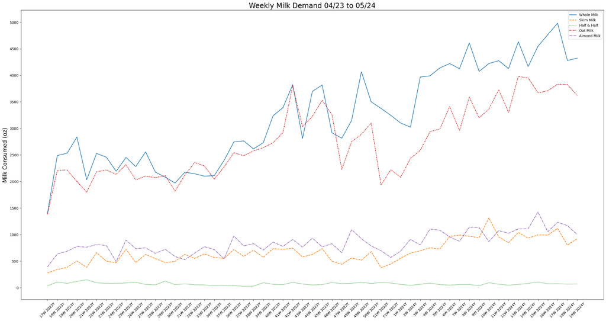

```python
plt.figure(figsize=(30,15))
ax = sns.lineplot(data=summ_week_milk_demand.iloc[:-1][['Whole Milk', 'Skim Milk', 'Half & Half', 'Oat Milk', 'Almond Milk']])
ax.set_xticks(range(len(summ_week_milk_demand.iloc[:-1]['Week-Year'])))
ax.set_xticklabels(summ_week_milk_demand.iloc[:-1]['Week-Year'], rotation=45)
ax.set_yticks(range(0,5001,500))
ax.set_yticklabels(range(0,5001,500))
ax.set_ylabel('Milk Consumed (oz)', size=16)
ax.set_title('Weekly Milk Demand 04/23 to 05/24', size=20)
```

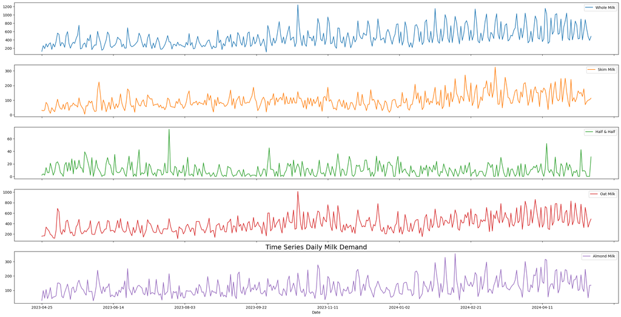

```python
summ_day_milk_demand.plot(subplots=True, x='Date', figsize=(30,15))
plt.title('Time Series Daily Milk Demand', size=18)
plt.show()
```

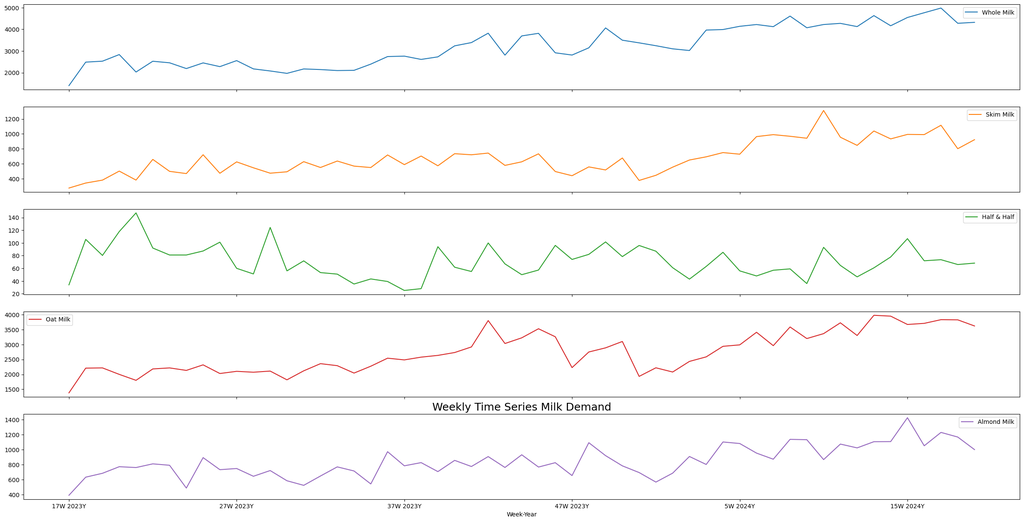

```python
summ_week_milk_demand.iloc[:-1].plot(subplots=True, x='Week-Year', y=['Whole Milk', 'Skim Milk', 'Half & Half', 'Oat Milk', 'Almond Milk'], figsize=(30,15))
plt.title('Weekly Time Series Milk Demand', size=18)
plt.show()
```

### Descriptive Statistics

We are going to start analizing and extracting key metrics from the data frames created in the previous steps. We will start with some descriptive statistics.

```python
# Perform descriptive statistics on daily demand
summ_day_milk_demand.describe()
```

|  | Whole Milk | Skim Milk | Half & Half | Oat Milk | Almond Milk |
| --- | --- | --- | --- | --- | --- |
| count | 385.000000 | 385.000000 | 385.000000 | 385.000000 | 385.000000 |
| mean | 463.700883 | 97.336597 | 10.222468 | 394.641403 | 121.552390 |
| std | 220.769160 | 50.870672 | 9.898060 | 155.153994 | 57.946786 |
| min | 107.600000 | 4.000000 | 0.000000 | 114.160000 | 27.300000 |
| 25% | 304.160000 | 63.970000 | 2.000000 | 281.180000 | 81.430000 |
| 50% | 408.480000 | 86.100000 | 8.000000 | 360.040000 | 109.260000 |
| 75% | 572.320000 | 119.630000 | 16.000000 | 475.660000 | 148.620000 |
| max | 1239.520000 | 326.020000 | 75.100000 | 1012.610000 | 355.390000 |

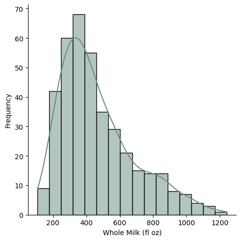

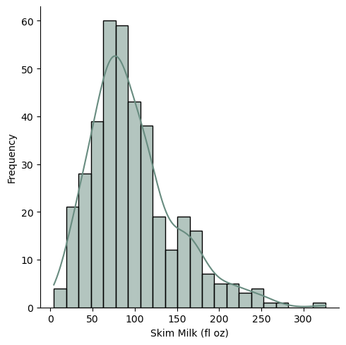

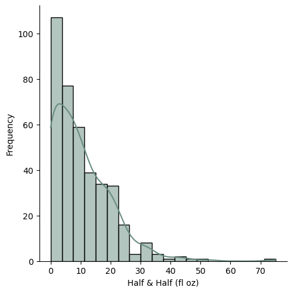

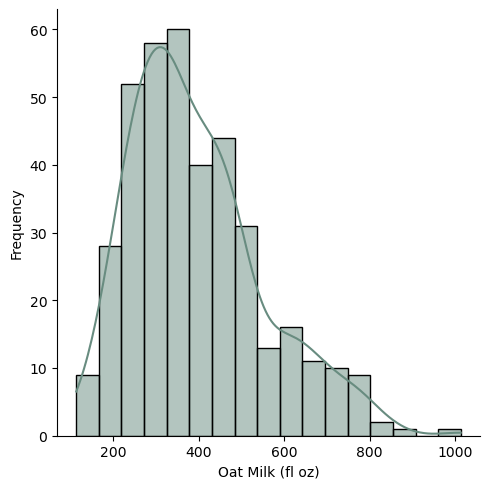

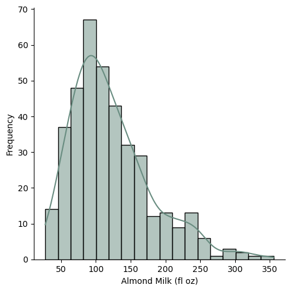

```python
# Create histograms for each type of milk
for col in summ_day_milk_demand.columns[1:]:
    ax = sns.displot(summ_day_milk_demand[col], color='#688c80', kde=True)
    ax.set_xlabels(col + ' (fl oz)')
    ax.set_ylabels('Frequency')
```

From the previously generated histograms, we can see that the demand for most milk types behaves in a similar way (except for the demand for half and half). Their distribution curves resemble a right-skewed normal distribution. For the next steps, we'll generate a boxplot for each milk type to identify and locate outliers.

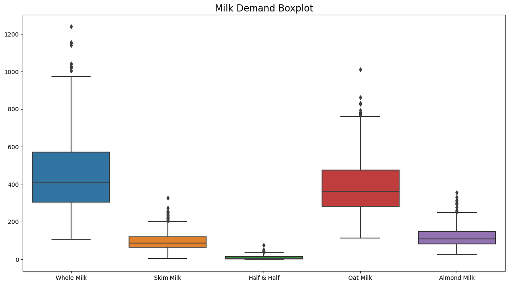

```python
# Create boxplots
plt.figure(figsize=(15,8))
ax = sns.boxplot(summ_day_milk_demand[1:])
ax.set_title('Milk Demand Boxplot', size=16)
```

As we can can see, there are several outliers in the milk demand. These extreme point can be the reason why our data is skewed. Lets remove these entries and plot the histograms again. We are going to use the built in function in `matplotlib.cbook` called `boxplot_stats`.

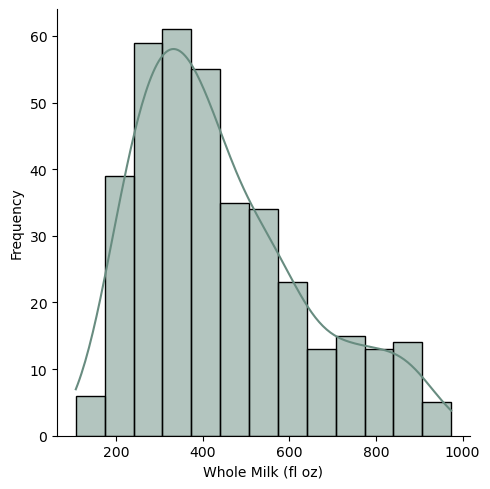

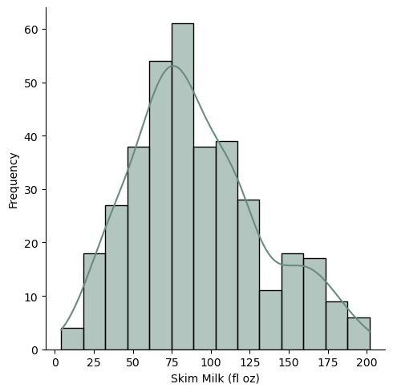

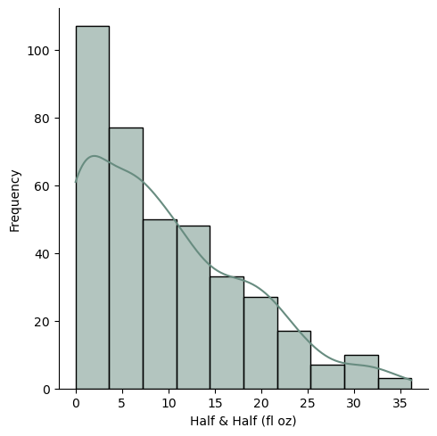

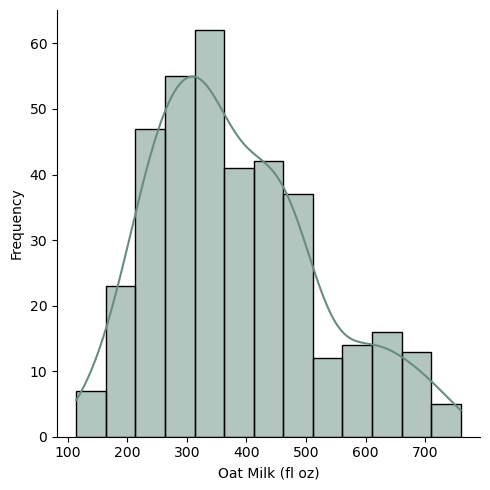

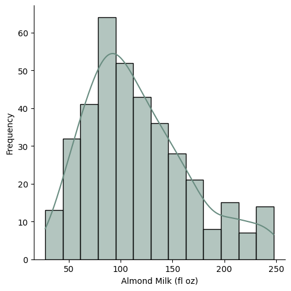

```python
for col in summ_day_milk_demand.columns[1:]:
    outliers = boxplot_stats(summ_day_milk_demand[col])[0]['fliers']
    m = ~summ_day_milk_demand[col].isin(outliers)
    ax = sns.displot(summ_day_milk_demand.loc[m][col], color='#688c80', kde=True)
    ax.set_xlabels(col + ' (fl oz)')
    ax.set_ylabels('Frequency')
    ax.set_titles('Milk Demand Without Outliers', size=16)
```

After removing the extreme values, our distribution plots are now slightly less right-skewed. This adjustment provides a clearer view of the data’s central tendency and spread. Next, we’ll continue by developing our procurement system for milk inventory.

### Inventory System

For milk restocking, I chose a **"Periodic Review System"**. This system involves the reviewing of stock levels at a fixed interval of time and placing replenishment orders at the end of each period. The replenishment quantity is variable and corresponds to the amount of stock required to bring the stock ordered and the stock on hand up to target level. The key variable for the system are:

- `T`: the review period
- `TI`: the target inventory level

Calculating `TI` with the following formula: $$ TI = \underbrace{\mu_d(T + L)}_{\text{Average demand during T and lead time}} + \underbrace{Z\sigma_d\sqrt{(T + L)}}_{\text{Safety Stock}}$$

*Where*:

- $ \mu_d $ = Average daily demand
- $ T $ = Review period in days
- $ L $ = Lead time in days
- $ Z $ = Z-score for wanted confidence level
- $ \sigma_d $ = Standard deviation for daily demand

This replenishment system was chosen for milk restocking because it aligns with the two fixed delivery and ordering cut-off days each week. This setup closely matches the model's requirements, ensuring a steady supply of fresh milk products. As a result, the risk of waste due to spoilage is significantly reduced, thanks to the consistent replenishment of inventory. The following are the values of each variable used to generate the milk restocking guidelines:

- $ \mu_d $ = Varies with milk type
- $ T $ = We are going to create 2 scenarios, one when we order twice a week and one weekly
- $ L $ = For both scenarios supplier have a lead time of 1 day
- $ Z $ = We are going to use z-score for a confidence level of 85%, 90%, and 95%
- $ \sigma_d $ = Varies with milk type

```python
lead = 1 # 1 day lead time
period = [3.5, 7] # Order weekly and twice per week
con_level = {'85%':1.083,'90%': 1.645, '95%': 1.96} # Dictionary with confidence level and their respective z-score

for col in summ_day_milk_demand.columns[1:]: # For loop to iterate through all milk type columns
    print(col)
    outliers = boxplot_stats(summ_day_milk_demand[col])[0]['fliers'] # Get array with ouliers
    m = ~summ_day_milk_demand[col].isin(outliers) # Create mask to filter out the outliers
    miu = summ_day_milk_demand.loc[m][col].mean() # Get average daily demand
    std = summ_day_milk_demand.loc[m][col].std() # Get standard deviation of daily demand

    if col == 'Oat Milk' or col == 'Almond Milk': # Oat and almond milk are ordered in boxes
        r = 1/(32*12) # Convert units from fluid ounces to boxes
        unit = 'Boxes'

    elif col == 'Half & Half': # Half and half is ordered in quarts
        r = 1/32 # Convert units from ounces to quarts
        unit = 'Quarts'

    else: # Whole and skim milk are ordered in half gallons
        r = 1/64 #Convert units from ounces to half gallons
        unit = 'Half Gal'

    for p in period: # Start loop to iterate through every ordering scenario
        print(f'Ordering Period {p} days:')
        for z in con_level.keys(): # Iterate through all confidence levels
            ss = math.ceil((con_level[z] * std * np.sqrt(p + lead))*r) # Calculate safety stock
            t = math.ceil((miu*(p + lead))*r) + ss # Calculate target inventory level
            print(f'Confidence Level {z}: Safety Stock = {ss} {unit}, T = {t} {unit}')
    print('')
```

```
Whole Milk
Ordering Period 3.5 days:
Confidence Level 85%: Safety Stock = 7 Half Gal, T = 39 Half Gal
Confidence Level 90%: Safety Stock = 11 Half Gal, T = 43 Half Gal
Confidence Level 95%: Safety Stock = 13 Half Gal, T = 45 Half Gal
Ordering Period 7 days:
Confidence Level 85%: Safety Stock = 10 Half Gal, T = 66 Half Gal
Confidence Level 90%: Safety Stock = 14 Half Gal, T = 70 Half Gal
Confidence Level 95%: Safety Stock = 17 Half Gal, T = 73 Half Gal

Skim Milk
Ordering Period 3.5 days:
Confidence Level 85%: Safety Stock = 2 Half Gal, T = 9 Half Gal
Confidence Level 90%: Safety Stock = 3 Half Gal, T = 10 Half Gal
Confidence Level 95%: Safety Stock = 3 Half Gal, T = 10 Half Gal
Ordering Period 7 days:
Confidence Level 85%: Safety Stock = 2 Half Gal, T = 14 Half Gal
Confidence Level 90%: Safety Stock = 4 Half Gal, T = 16 Half Gal
Confidence Level 95%: Safety Stock = 4 Half Gal, T = 16 Half Gal

Half & Half
Ordering Period 3.5 days:
Confidence Level 85%: Safety Stock = 1 Quarts, T = 3 Quarts
Confidence Level 90%: Safety Stock = 1 Quarts, T = 3 Quarts
Confidence Level 95%: Safety Stock = 2 Quarts, T = 4 Quarts
Ordering Period 7 days:
Confidence Level 85%: Safety Stock = 1 Quarts, T = 4 Quarts
Confidence Level 90%: Safety Stock = 2 Quarts, T = 5 Quarts
Confidence Level 95%: Safety Stock = 2 Quarts, T = 5 Quarts

Oat Milk
Ordering Period 3.5 days:
Confidence Level 85%: Safety Stock = 1 Boxes, T = 6 Boxes
Confidence Level 90%: Safety Stock = 2 Boxes, T = 7 Boxes
Confidence Level 95%: Safety Stock = 2 Boxes, T = 7 Boxes
Ordering Period 7 days:
Confidence Level 85%: Safety Stock = 2 Boxes, T = 10 Boxes
Confidence Level 90%: Safety Stock = 2 Boxes, T = 10 Boxes
Confidence Level 95%: Safety Stock = 3 Boxes, T = 11 Boxes

Almond Milk
Ordering Period 3.5 days:
Confidence Level 85%: Safety Stock = 1 Boxes, T = 3 Boxes
Confidence Level 90%: Safety Stock = 1 Boxes, T = 3 Boxes
Confidence Level 95%: Safety Stock = 1 Boxes, T = 3 Boxes
Ordering Period 7 days:
Confidence Level 85%: Safety Stock = 1 Boxes, T = 4 Boxes
Confidence Level 90%: Safety Stock = 1 Boxes, T = 4 Boxes
Confidence Level 95%: Safety Stock = 1 Boxes, T = 4 Boxes
```

### Milk Periodic Ordering System

Above is the safety stock and target inventory level (T) for each milk type, based on different confidence levels. The ordering period can be either once or twice a week. For milk, we'll order twice a week due to space limitations and to minimize the risk of spoilage.

The order quantity is calculated as:

$$ Q = Target Level - Current Stock $$

### Implementation

A closing report one day before the ordering deadline should include the current stock levels of each milk type. Using the order quantity formula, calculate the quantity to order for each type of milk.

Example:

Delivery Day: Tuesday Ordering Due Date: Monday, 2 p.m.

#### Target Levels

| **Milk Type** | **Target Level 90%** |
| --- | --- |
| Whole Milk | 43 Half Gallons |
| Skim Milk | 10 Half Gallons |
| Half & Half | 3 Quarts |
| Oat Milk | 7 Boxes |
| Almond Milk | 3 Boxes |

#### Sunday’s Closing Report

| **Milk Type** | **Current Stock** |
| --- | --- |
| Whole Milk | 12 Half Gallons |
| Skim Milk | 6 Half Gallons |
| Half & Half | 1 Quart |
| Oat Milk | 2 Boxes |
| Almond Milk | 1 Box |

#### Monday’s Order Before 2 p.m. (90% Confidence Level)

| **Milk Type** | **Q = Target Level - Current Stock** |
| --- | --- |
| Whole Milk | Q = 43 - 12 = 31 Half Gallons |
| Skim Milk | Q = 10 - 6 = 4 Half Gallons |
| Half & Half | Q = 3 - 1 = 2 Quarts |
| Oat Milk | Q = 7 - 2 = 5 Boxes |
| Almond Milk | Q = 3 - 1 = 2 Boxes |

## Conclusion

By integrating these insights with inventory theory, I have uncovered valuable opportunities to optimize processes throughout the company. Consolidating all the various procurement systems into a standardized inventory manual will streamline processes and enhance control over purchasing operations. Additionally, gaining a comprehensive understanding of material behavior across all stores will enable the company to pursue vertical integration and potentially establish its own distribution center. This move is expected to reduce material costs and increase profit margins.